# 13_APU_TFs

2025-03-13

Promoter Distribution Analysis This section integrates CAGE-seq data from the Eukaryotic Promoter Database (EPD) with TF and RNA-binding protein (RBP) reference lists.

Quantification: The script calculates the number of unique promoters associated with each gene (Ensembl ID).

Binning: Genes are categorized into discrete groups (1, 2, 3, 4, 5+) and a binary classification (Single vs. Multi-promoter).

Visualisation: Bar charts illustrate the global distribution of promoter counts, revealing how many genes in the MCF-7 line utilize multiple transcription start sites.

```r
#Load MCF7 CAGE seq

###---------------
#LOAD LIBRARIES
###----------------
library(readr)
library(pROC)
```

```r
library(cowplot)
library(ggpubr)
library(tidyr)
library(clusterProfiler)
library(enrichplot)
library(ggplot2)
library(broom)
library(dplyr)
library(org.Hs.eg.db)
# Define colors
color1 <- "#4d00c7"
palecolor1 <- "#b366ff"
color2 <- "#da3c07"
palecolor2 <- "#ff8954"
color3 <- "#05d3d3"
color4 <- "#c6c7c5"
color5 <- "black"

#make palette 15 longer
pal_1 <- c("#FC8B9F","#89B432","#645AA4","#F6E6BD", "#EE5A5A", "#315A7B", "#31573F", "#DE73CD",
           "#81B9E5","#F7A5A7", "#801E1E", "#FF8B00", "#FFB300", "#FFDA00", "#A3D8E0" )
palette_1 <- c( "#3E7BBF",  "#E55352", "#801E1E", "#81B9E5","#F7A5A7", "#F37374", "#0F4B82", "#5A9BD3",   "#315A7B","#31573F")
```

```r
# Read the CSV file
#check https://humantfs.ccbr.utoronto.ca/download/v_1.01/TFs_Ensembl_v_1.01.txt#https://humant fs.ccbr.utoronto.ca/download.php
EPD_CAGE <- readr::read_csv("../../../alt-prom-crispr-fiveprime/files/reference/ENCFF917XEM_EPD.csv")
```

```
## ──────────────────────────────────────────────────────── Delimiter: "," chr
## (6): chr, strand, ref_TSSchr, ref_TSSID, ensembl_id, Gene_symbol dbl (11):
## ...1, start, end, pVal, qVal, peak1, peak2, ref_TSSstart, ref_TSSe...
```

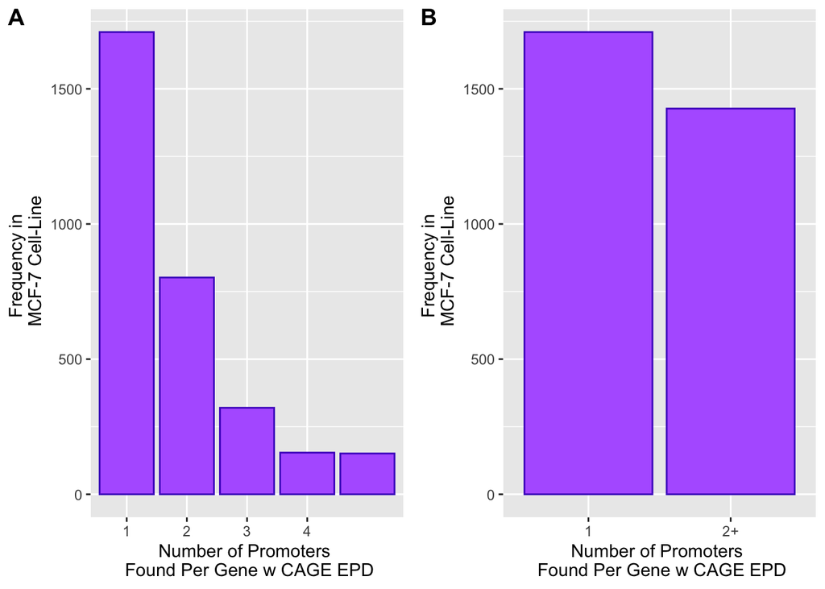

```r
human_tfs <- read.table("../../../alt-prom-crispr-fiveprime/files/reference/TFs_Ensembl_v_1.01.txt" ,header = TRUE, sep = "\t", skip = 1)
rbps <- read.csv("../../../alt-prom-crispr-fiveprime/files/reference/RBPbase_Download_2025-03-14.csv" ,header = TRUE)
loc <- "../../../alt-prom-crispr-fiveprime/files/bulk_rnaseq/"


# Count occurrences per gene
grouped <- EPD_CAGE %>%
  group_by(ensembl_id) %>%
  summarise(count_num = n())

#group together any genes that have over 6
grouped$count_num_discrete <- ifelse(grouped$count_num > 4, "5+", as.character(grouped$count_num))
grouped$count_num_binary <- ifelse(grouped$count_num > 1, "2+", as.character(grouped$count_num))

# Create count plot
a <- ggplot(grouped, aes(x = factor(count_num_discrete))) +  # Treat x-axis as categorical
  geom_bar(fill = palecolor1, color = color1) +
  scale_x_discrete(breaks = c("1", "2", "3", "4", "5","6","7+")) +  # Show only discrete ticks
  labs(x = "Number of Promoters \n Found Per Gene w CAGE EPD",
       y = "Frequency in \n MCF-7 Cell-Line")
b <- ggplot(grouped, aes(x = factor(count_num_binary))) +  # Treat x-axis as categorical
  geom_bar(fill = palecolor1, color = color1) +
  scale_x_discrete(breaks = c("1", "2+")) +  # Show only discrete ticks
  labs(x = "Number of Promoters \n Found Per Gene w CAGE EPD",
       y = "Frequency in \n MCF-7 Cell-Line")

ggarrange(a, b, ncol = 2, nrow = 1, #labbel A and B
          labels = c("A", "B"))
```

```r
#look at the genes expressing two or more promoters
genes <- grouped %>%
  mutate(count_num = as.numeric(count_num)) %>% #sort by count
  filter(count_num > 1)
#sort accourting to count_num
genes <- genes[order(genes$count_num, decreasing = TRUE),]
```

```r
#get the expression of the genes it iterating through "files/bulk_rnaseq/SGNex_MCF7_Illumina_replicate2_run1.gene.tpm.gz"  import and make a column in the
count_start=0
for (sample_name in list.files(loc, pattern="gene", full.names = TRUE)){
  if (count_start == 0){
    print(sample_name)
       sample <- read_table(sample_name) #remove loc at beginning of sample name and .gene.tpm.gz at the end
       strstr <- strsplit(sample_name, "/")[[1]][10]
       sample_name_str <- as.character(strsplit(strstr, ".gene.tpm.gz")[1])
        #change the colnames add sample name to TpM and read counts
       sample$sample_name <- sample_name_str
       count_start <- count_start + 1
     } else {
       sample2 <- read_table(sample_name)
       sample2$sample_name <- sample_name
       sample <- rbind(sample, sample2)
     }
}
```

```
## [1] "../../../alt-prom-crispr-fiveprime/files/bulk_rnaseq//SGNex_MCF7_Illumina_replicate2_run1.gene.tpm.gz"
```

```r
#make so that there is only TPM for each sample with genes as each row
sample_matrix <- sample %>% as.data.frame() %>%
  dplyr::select(Gene, sample_name, TpM) %>% #pivot wider
  pivot_wider(names_from = sample_name, values_from = TpM) %>%
  tibble::column_to_rownames(var = "Gene") %>%
  as.data.frame() %>% mutate(mean_TpM = rowMeans(.[,1:ncol(.)], na.rm = TRUE))

expressed <- sample_matrix %>% filter(mean_TpM > 5) %>% rownames() %>% as.data.frame()
#make a liust of genes that are exprssed above 5 TPM
write_delim(sample_matrix %>% filter(mean_TpM > 5) %>% rownames() %>% as.data.frame(), "/Users/helenking/Documents/Weatheritt_Lab/alternative-promoter-identification/annotations/CAGE/genes_expressed_above_5.txt")
#left merge sample_matrix with genes grouped
sample_matrix <- merge(sample_matrix, grouped, by.x = "row.names", by.y="ensembl_id", all.y = TRUE)

#YN is there TFs
sample_matrix$TF <- ifelse(sample_matrix$Row.names %in% human_tfs$DUX3_HUMAN, "TF", "Non-TF")
#there are sometimes | in the gene names so need to remove them and expand
rbps_list <- strsplit(rbps$ID, "\\|") %>% unlist() %>% unique()
sample_matrix$RBPS <- ifelse(sample_matrix$Row.names %in% rbps_list, "RBP", "Non-RBP")
sample_matrix_final <- sample_matrix
```

Modeling Expression vs. Promoter Complexity This block explores whether genes with more promoters are more highly expressed or regulated differently.

Violin Plots (A): Compares mean TPM between single and multi-promoter genes, stratified by TF status. Statistical significance is assessed using Bonferroni-adjusted t-tests.

Regression Analysis (B): A regression model quantifies the correlation between the absolute number of promoters and the mean gene expression, utilizing a log10 scale for clarity.

```r
# Count the number of samples per group
sample_counts <- sample_matrix %>%
  group_by(count_num_binary,TF) %>%
  summarise(n = n())
```

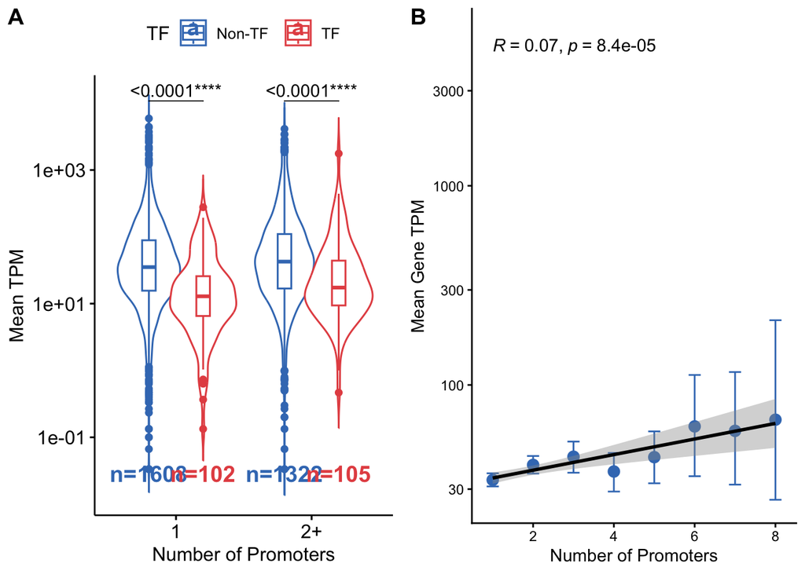

```r
# Create the violin plot
a <- ggviolin(sample_matrix[order(sample_matrix$count_num, decreasing = FALSE),],
              x = "count_num_binary", y = "mean_TpM", color = "TF",
              ylab = "Mean TPM", xlab = "Number of Promoters",
              yscale = "log10", palette = c("#3E7BBF", "#E55352"),
              add = "boxplot", add.params = list(fill = "white")) +
  # Add statistical comparisons
  geom_pwc(aes(group = TF), tip.length = 0,
           method = "t_test", label = "{p.adj.format}{p.adj.signif}",
           p.adjust.method = "bonferroni", p.adjust.by = "group",
           hide.ns = TRUE) +

  # Add sample size labels for both `count_num_binary` and `TF`
  geom_text(data = sample_counts, aes(x = count_num_binary, y = 0.05,
                                      label = paste0("n=", n), color = TF),
            position = position_dodge(width = 0.8), vjust = 1.5, size = 5, fontface = "bold")

b <- ggplot(sample_matrix %>% filter(count_num < 9), aes(x = count_num, y = mean_TpM)) +
  stat_summary(fun = mean, geom = "point", size = 3, color = "#3E7BBF") +
  stat_summary(fun.data = mean_cl_boot, geom = "errorbar", width = 0.3, color = "#3E7BBF") +
  geom_smooth(method = "lm", se = TRUE, color = "black") +
  scale_y_log10() +
  labs(x = "Number of Promoters", y = "Mean Gene TPM") +
  theme_classic() + #add regression
  stat_cor(aes(), label.x = 1)
#plot
cowplot::plot_grid(a, b, ncol = 2, labels = c("A", "B"), #make larger
                   rel_heights = c(1, 1))
```

```r
#actually calculate the p-value bonferroini
#with geom_pwc

# Compute Bonferroni-adjusted pairwise t-tests
pval_table <- compare_means(
  formula = mean_TpM ~ TF,
  data = sample_matrix,
  group.by = "count_num_binary",
  method = "t.test",
  p.adjust.method = "bonferroni"
)

# View the result
print(pval_table)
```

```
## # A tibble: 2 × 9
##   count_num_binary .y.   group1 group2        p   p.adj p.format p.signif method
##   <chr>            <chr> <chr>  <chr>     <dbl>   <dbl> <chr>    <chr>    <chr>
## 1 2+               mean… Non-TF TF     5.42e- 5 1.1e- 4 5.4e-05  ****     T-test
## 2 1                mean… Non-TF TF     4.02e-19 8  e-19 < 2e-16  ****     T-test
```

Transcription Factor Prevalence Analysis Focusing on the subset of expressed genes (TPM > 5), this block visualizes TF density.

Absolute Counts (C): A stacked bar chart showing the raw number of genes at each promoter level.

Proportional Shifts (D): A filled bar chart showing the proportion of TFs vs. non-TFs. This visualization highlights a key finding: as the number of promoters increases, the proportion of genes that are Transcription Factors also rises significantly.

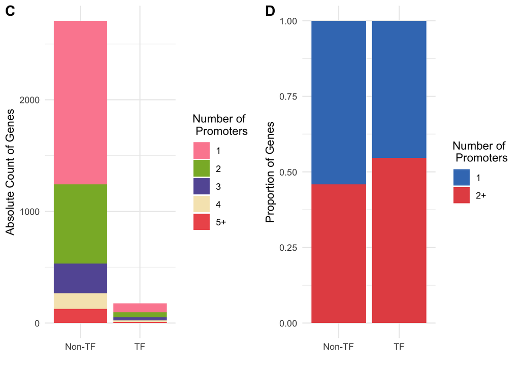

```r
#filter for the TPM above 5


sample_matrix_sub <- sample_matrix %>% filter(mean_TpM > 5)
 #do count plot of the number of genes that are TF per promoter
a <- sample_matrix_sub %>% group_by(count_num_discrete, TF) %>%
  ggplot(aes(x = TF, fill = count_num_discrete )) + #plot the percentage population
  geom_bar(stat = "count", position = "stack") +
  labs(y = "Absolute Count of Genes", x = "", fill = "Number of \n Promoters") +
  theme_minimal() +  #add palette
  scale_fill_manual(values = pal_1)
#do count plot of the number of genes that are TF per promoter
b <- sample_matrix_sub %>% group_by(count_num_binary, TF) %>% summarise(n = n()) %>%
  ggplot(aes(x = TF, y = n, fill = count_num_binary )) + #plot the percentage population
  geom_bar(stat = "identity", position = "fill") +
  labs(y = "Proportion of Genes", x = "", fill = "Number of \n Promoters") +
  theme_minimal() + #add palette
  scale_fill_manual(values = palette_1)
#statsitcal test between proportion

ggarrange(a, b, ncol = 2, nrow = 1, #labbel A and B
          labels = c("C", "D"))
```

This section moves beyond visualization to formal enrichment testing. Using a Fisher’s Exact Test and a Chi-squared test, the script calculates whether multi-promoter usage is statistically “enriched” in Transcription Factors compared to the rest of the genome.

```r
#fishers exact test
mosaic_data <- sample_matrix_sub %>% group_by(count_num_binary, TF) %>% summarise(n = n()) %>% #make pivot table
  pivot_wider(names_from = TF, values_from = n) %>% as.data.frame()
rownames(mosaic_data) <- mosaic_data$count_num_binary
mosaic_data <- mosaic_data %>% dplyr::select(-count_num_binary)

print(fisher.test(mosaic_data))
```

```
##
##  Fisher's Exact Test for Count Data
##
## data:  mosaic_data
## p-value = 0.02874
## alternative hypothesis: true odds ratio is not equal to 1
## 95 percent confidence interval:
##  1.032653 1.952436
## sample estimates:
## odds ratio
##   1.418346
```

```r
print(chisq.test(mosaic_data)$expected)
```

```
##      Non-TF       TF
## 1  1452.592 94.40777
## 2+ 1255.408 81.59223
```

```r
print(mosaic_data)
```

```
##    Non-TF TF
## 1    1467 80
## 2+   1241 96
```

Logistic Regression & Predictive Modeling To determine the predictive power of promoter counts, a logistic regression model is fitted to the data.

Probability Curve: The model estimates the probability of a gene being a TF based solely on its promoter count.

Performance Evaluation: An ROC (Receiver Operating Characteristic) curve is plotted, and the AUC (Area Under the Curve) is calculated to measure how accurately promoter complexity can distinguish TFs from other genes.

```r
#count the number of promoters per gene and the number of genes that are TFs
sample_matrix_pergene <- sample_matrix_sub %>% dplyr::select(TF, count_num, count_num_discrete, Row.names) %>%
  mutate(TF_binary = ifelse(TF == "TF", 1, 0))


# Fit logistic regression model
model <- glm(TF_binary ~ count_num, data = sample_matrix_pergene, family = binomial)
summary(model)
```

```
##
## Call:
## glm(formula = TF_binary ~ count_num, family = binomial, data = sample_matrix_pergene)
##
## Coefficients:
##             Estimate Std. Error z value Pr(>|z|)
## (Intercept) -2.92760    0.12576 -23.280   <2e-16 ***
## count_num    0.09895    0.04799   2.062   0.0392 *
## ---
## Signif. codes:  0 '***' 0.001 '**' 0.01 '*' 0.05 '.' 0.1 ' ' 1
##
## (Dispersion parameter for binomial family taken to be 1)
##
##     Null deviance: 1325.4  on 2883  degrees of freedom
## Residual deviance: 1321.6  on 2882  degrees of freedom
## AIC: 1325.6
##
## Number of Fisher Scoring iterations: 5
```

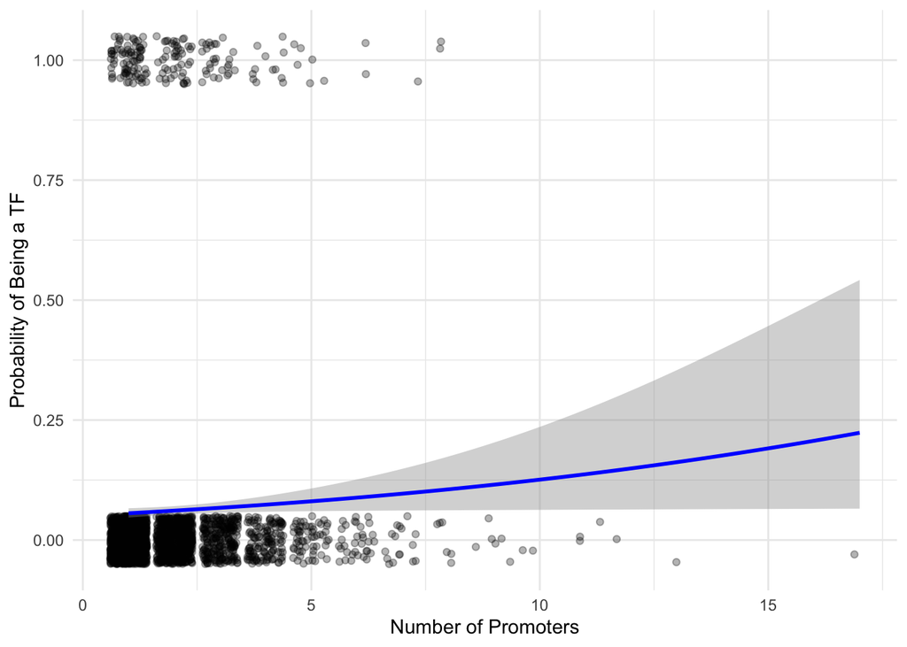

```r
#plot

# Predict probabilities
sample_matrix_pergene$predicted_prob <- predict(model, type = "response")

# Plot
ggplot(sample_matrix_pergene, aes(x = count_num, y = TF_binary)) +
  geom_jitter(height = 0.05, alpha = 0.3) +  # Jitter points for better visibility
  geom_smooth(method = "glm", method.args = list(family = "binomial"), se = TRUE, color = "blue") +
  labs(x = "Number of Promoters", y = "Probability of Being a TF") +
  theme_minimal()
```

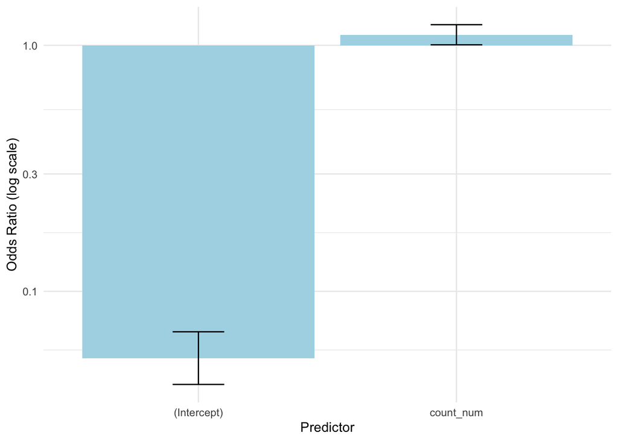

```r
tidy(model) %>%
  mutate(OR = exp(estimate), lower = exp(estimate - 1.96 * std.error), upper = exp(estimate + 1.96 * std.error)) %>%
  ggplot(aes(x = term, y = OR)) +
  geom_col(fill = "lightblue") +
  geom_errorbar(aes(ymin = lower, ymax = upper), width = 0.2) +
  scale_y_log10() +
  labs(x = "Predictor", y = "Odds Ratio (log scale)") +
  theme_minimal()
```

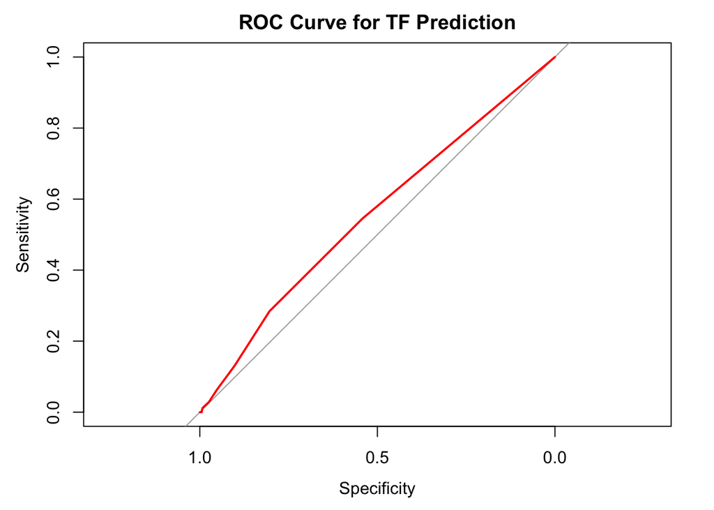

```r
roc_curve <- roc(sample_matrix_pergene$TF_binary, predict(model, type = "response"))
plot(roc_curve, col = "red", main = "ROC Curve for TF Prediction")
```

```r
auc(roc_curve)  # Get AUC value
```

```
## Area under the curve: 0.554
```

```r
head(sample_matrix_final)
```

```
##         Row.names    NA
## 1 ENSG00000000419 225.4
## 2 ENSG00000001036  69.6
## 3 ENSG00000001460   5.8
## 4 ENSG00000001617  26.3
## 5 ENSG00000002549  36.1
## 6 ENSG00000003056 185.0
##   ../../../alt-prom-crispr-fiveprime/files/bulk_rnaseq//SGNex_MCF7_Illumina_replicate3_run1.gene.tpm.gz
## 1                                                                                                 146.0
## 2                                                                                                  50.3
## 3                                                                                                   6.7
## 4                                                                                                  30.6
## 5                                                                                                  13.8
## 6                                                                                                  43.7
##   ../../../alt-prom-crispr-fiveprime/files/bulk_rnaseq//SGNex_MCF7_Illumina_replicate4_run1.gene.tpm.gz
## 1                                                                                                 191.0
## 2                                                                                                  56.1
## 3                                                                                                   6.0
## 4                                                                                                  36.4
## 5                                                                                                  30.7
## 6                                                                                                 160.7
##     mean_TpM count_num count_num_discrete count_num_binary     TF    RBPS
## 1 187.466667         2                  2               2+ Non-TF Non-RBP
## 2  58.666667         2                  2               2+ Non-TF     RBP
## 3   6.166667         1                  1                1 Non-TF Non-RBP
## 4  31.100000         3                  3               2+ Non-TF Non-RBP
## 5  26.866667         2                  2               2+ Non-TF     RBP
## 6 129.800000         3                  3               2+ Non-TF     RBP
```